# Chapter 3: Splines

# Problem 1

## a. Determine whether the function is a linear spline

Let’s check the properties. First of all it does have a degree of 1 or less on each piece of the polynomial, so that property passes. Next let’s check for continuity on the inner knots.

At x = 0.5, $S_0(0.5) = 0.5$ and $S_1(0.5) = 0.5 = 2 * 0 = 0.5$. Continuous here.

At x = 2, $S_1(2) = 0.5 + 2 * 1.5 = 3.5$ and $S_2(2)=2 + 1.5 = 3.5$. Continuous here.

This function S(x) must then be a linear spline.

## b. Do there exist a,b,c,d so the function is a natural cubic spline?

Recall that a natural cubic spline uses the condition that the second derivative at the end knots both equal to zero.

Let’s set up our system:

$$S_0''(-1) = 6ax + 2 = 0$$
$$-6a = -2$$
$$a = \frac23$$

$$S_1''(1) = 6bx + 2 = 0$$
$$6b = -2$$
$$b = -\frac23$$

So yes, there do exist an a,b,c, and d so the function is a natural cubic spline. If a = 2/3 and b = -2/3, then the two end points are points of inflection.

## c. Determine whether f is a cubic spline with knots -1, 0, 1, and 2

First of all we can confirm that each piece of the function is degree 3 or less. Second let’s test for continuity between knots.

At 0:

$$S_0(0) = S_1(0)$$
$$1 + 2(0+1) + (0+1)^3=3+5*0+3*0$$
$$1 + 2 + 1 = 3$$
$$3 = 3$$

That works, next at 1:

$$S_1(1) = S_2(1)$$
$$3 + 5 + 3 = 11 + 0 + 3 * 0 + 0$$
$$11 = 11$$

That works, check first derivative at 0:

$$S_0'(0) = S_1'(0)$$
$$2+3(0+1)^2=5 + 6 * 0$$
$$2 + 3 = 5$$
$$5 = 5$$

That works, next at 1:

$$S_1'(1) = S_2'(1)$$
$$5 + 6 * 1 = 6(1-1)+3(1-1)^2+1$$
$$5 \ne 1$$

Therefore the function f is NOT a cubic spline, since it is not (k-1) times differntiable at it’s inner knots.

## d. Determine the values of a,b,c such that the function is a linear spline.

Let’s create our system of equations (for three unknowns).

$$S_0(-1) = s_1(-1)$$
$$S_1(0) = S_2(0)$$
$$S_2(1) = s_3(1)$$

Now let’s solve one at a time from the end.

$$c(1) + 3(1-1) = 4$$
$$c = 4$$

Now that we know c is four let’s move to the second equation.

$$a(0 + 1) + b * 0 = 4 * 0 + 3(0-1)$$
$$a = -3$$

Then move on to our first equation we wrote.

$$-3(-1 + 1) + b * -1 = -1 + 1$$
$$-b = 0$$
$$b = 0$$

So we can conclude taht a = -3, b = 0, and c = 4 gives us a linear spline.

## e. Determine the values of a,b,c such that the function is a linear spline.

Let’s create our system of equations (for three unknowns).

$$S_0(-1) = s_1(-1)$$
$$S_1(0) = S_2(0)$$
$$S_2(1) = s_3(1)$$

Now let’s solve one at a time from the the end.

$$c(1) + 2(1-1) = 5$$
$$c = 5$$

Now we know c is five let’s move to the second equation.

$$a(0+1) + b * 0 = 5*0 + 2(0-1)$$
$$a=-2$$

Then move on to our first equation we wrote.

$$-1 + 3 = -2(-1 + 1) + b * -1$$
$$2 = -b$$
$$b=-2$$

So we can conclude that a = b = -2, and c = 5 gives us a linear spline.

# Problem 2

Given a set of data

$$\begin{tabular}{c|c|c|c|c|c}
t$_i$ & 1.2 & 1.5 & 1.6 & 2.0 & 2.2\\
y$_i$ & 0.4275 & 1.139 & 0.8736 & -0.9751 & -0.1536
\end{tabular}$$

## a.

Let L(x) be the linear spline that interpolates the data. Describe what L(x) consists of, and what conditions it has to satisfy. Find L(x), and compute the value for L(1.8).

There are two main conditions a linear spline would have to fulfill. It would have to be of degree 1 polynomial on each piece, and L(x) would have to be continous at each knot denoted in the table.

For a linear spline we can just use the equation of a linear point as written:

$$S_i(x) = y_i + \frac{y_{i+1}-y_i}{t_{i+1}-t_i}(x-t_i)$$

For i = 0:

$$S_0(x) = 0.4275 + \frac{1.139 - 0.4275}{1.5-1.2}(x-1.2)$$
$$S_0(x) = 0.4275 + 2.3717(x-1.2)$$

For i = 1

$$S_1(x) = 1.139 + \frac{0.8736 - 1.139}{1.6-1.5}(x-1.5)$$
$$S_1(x) = 1.139 - 2.654(x-1.5)$$

For i = 2

$$S_2(x) = 0.8736 + \frac{-0.9751 - 0.8736}{2.0-1.6}(x-1.6)$$
$$S_2(x) = 0.8736 - 4.6218(x-1.6)$$

For i = 3

$$S_3(x) = -0.9751 + \frac{-0.1536 + 0.9751}{2.2-2.0}(x-2.0)$$
$$S_3(x) = -0.9751 + 4.1075(x-2.0)$$

$$S(x) = \left\{
\begin{array}{ll}
0.4275 + 2.3717(x-1.2) & \quad 1.2 \leq x \leq 1.5 \\
1.139 - 2.654(x-1.5) & \quad 1.5 \leq x \leq 1.6 \\
0.8736 - 4.6218(x-1.6) & \quad 1.6 \leq x \leq 2.0\\
-0.9751 + 4.1075(x-2.0) & \quad 2.0 \leq x \leq 2.2
\end{array}
\right.$$

$$S(1.8) = S_2(1.8) = 0.8736 - 4.6218(1.8 - 1.6) = -0.05076$$

## b.

Let C(x) be the natural cubic spline that interploates the data. Describe what C(x) consists of, and what conditions it has to satisfy. Find C(x), and compute the value for C(1.8). The computation here can be time consuming, and you may use Matlab to solve the linear system.

C(x) is a piecewise function that consists of 4 3rd degree polynomials. The fuction C(x) must be continous up to twice differentiable. In our case we our looking for a natural cubic spline, so the end points must have a second derivative of zero.

$$S(x) = \left\{
\begin{array}{ll}
-18.8675x^3+4.0697x+0.4275 & \quad 1.2 \leq x \leq 1.5 \\
6.8546x^3-16.9807x^2-1.0245x+1.1390 & \quad 1.5 \leq x \leq 1.6 \\
34.7685x^3-14.9243x^2-4.2150x+0.8736 & \quad 1.6 \leq x \leq 2.0\\
-44.6632x^3+26.7979x^2+0.5344x-0.9751 & \quad 2.0 \leq x \leq 2.2
\end{array}
\right.$$

C(1.8) = -0.2882

# Problem 3

Write a Matlab function that computes the linear spline interpolation for a given data set. You might need to take a look at the file cspline_eval.m in section 3.4 for some hints. Name your Matlab function lspline. This can be defined in the file lspline.m.

Use your Matlab function lspline on the given data set in Problem 2, plot the linear spline for the interval [1.2, 2.2].

```
function S = cspline_eval(t,y,z,x_vec)
% function S = cspline_eval(t,y,z,x_vec)
% compute the value of the natural cubic spline at the points x_vec when
% t,y,z are given
%
% Example:   t = [0.9,1.3,1.9,2.1];
%            y = [1.3,1.5,1.85,2.1]
%            z = cspline(t,y)
%            x = [0.9:0.1:2.1]
%            v = cspline_eval(t,y,z,x)

m = length(x_vec);
S = zeros(size(x_vec));
n = length(t);
for j=1:m
  x = x_vec(j);
  for i=n-1:-1:1
    if (x-t(i)) >= 0
      break
    end
  end
  h = t(i+1)-t(i);
  S(j) = z(i+1)/(6*h)*(x-t(i))^3-z(i)/(6*h)*(x-t(i+1))^3 ...
       +(y(i+1)/h-z(i+1)*h/6)*(x-t(i)) - (y(i)/h-z(i)*h/6)*(x-t(i+1));
end
```

Input/Output:

lspline(t,y,t)

ans =

> > 0.4275 1.1390 0.8736 -0.9751 -0.1536

x = [1.4 1.5 1.6 1.7 1.8];

lspline(t,y,x)

ans =

> > 0.9018 1.1390 0.8736 0.4114 -0.0508

Which this 1.8 value is the same we got when manually evaluating the spline.

Script to make plot:

```
x = 1.2:0.1:2.2;
t = [1.2 1.5 1.6 2.0 2.2];
y = [0.4275 1.139 0.8736 -0.9751 -0.1536];

yVals = lspline(t,y,x);

figure
plot(x,yVals)
grid on
xlabel('Chosen Points')
ylabel('Linear Spline Points')
```

And the plot! If you compared adding extra points in the plot, that it does not change what is plotted, because you maintain the piecewise linear plot.

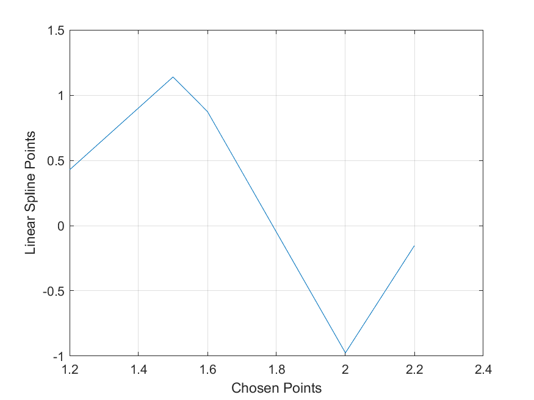

# Problem 4

I made a script that allows you to click the points on a screenshot of the image and it uses those points to run the spline interpolation that is then plotted. I clicked a series of twenty points, and more near the top in hopes that a higher resolution would make the top of the mountain sharper, since we konw that the cubic spline generates the smoothest interpolation. The peak does appear in the plot. I am including both the plot of the points and the Matlab printout of the points I clicked.

```
% display image
everest = imread('../Media/mountEverest.png');
image(everest)
grid on

% click knot points
[t, y] = ginput(20);
y = y.*-1;

z = cspline(t, y);

min = t(1);
max = t(20);
x = min:0.001:max;

yPlot = cspline_eval(t, y, z, x);

figure
plot(x, yPlot)
xlabel('Range of clicked points')
ylabel('Interpolated Points')
title('Interpolated ridge')
```

The points (x, y):

- 10.3318 -207.3163
- 32.3088 -188.9490
- 61.2258 -166.9082
- 95.9263 -141.1939
- 128.3134 -115.4796
- 173.4240 -81.6837
- 197.7143 -62.5816
- 212.7512 -52.2959
- 239.3548 -42.7449
- 252.0783 -44.9490
- 272.8986 -47.1531
- 287.9355 -61.1122
- 316.8525 -80.9490
- 337.6728 -110.3367
- 361.9631 -154.4184
- 373.5300 -186.7449
- 378.1567 -182.3367
- 389.7235 -173.5204
- 411.7005 -155.8878
- 462.5945 -218.3367

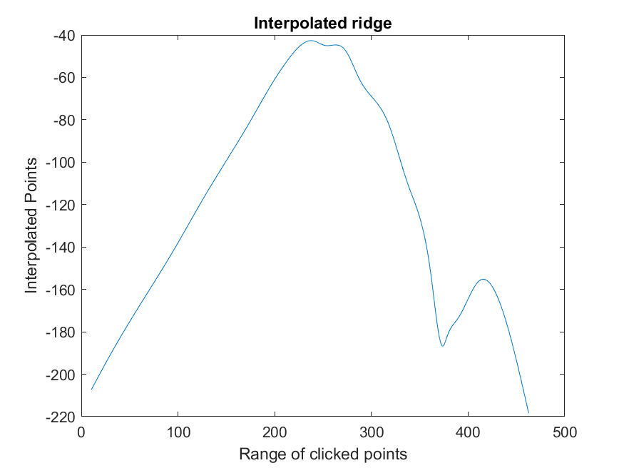